# CA4-Codes

تمرین کامپیوتری 4 - **ML**

**امیرحسین کهربائیان - 810199478**

```python
import pandas as pd
import numpy as np
import matplotlib.pyplot as plt
import sklearn.metrics as sm
import sklearn.feature_selection
from sklearn.neighbors import KNeighborsClassifier
from sklearn.linear_model import LogisticRegression
from sklearn import tree
from sklearn.ensemble import RandomForestClassifier
from sklearn.metrics import confusion_matrix, ConfusionMatrixDisplay
from sklearn.model_selection import GridSearchCV
from copy import deepcopy
import warnings
from mlxtend.evaluate import bias_variance_decomp
warnings.filterwarnings('ignore')
```

```python
Data = pd.read_csv("diabetes.csv")
Data
```

|  | Pregnancies | Glucose | BloodPressure | SkinThickness | Insulin | BMI | DiabetesPedigreeFunction | Age | Outcome |
| --- | --- | --- | --- | --- | --- | --- | --- | --- | --- |
| 0 | 6.0 | 148.0 | 72.0 | 35.0 | 0.0 | 33.6 | 0.627 | 50.0 | 1 |
| 1 | 1.0 | 85.0 | 66.0 | 29.0 | 0.0 | 26.6 | 0.351 | 31.0 | 0 |
| 2 | NaN | 183.0 | 64.0 | 0.0 | 0.0 | 23.3 | 0.672 | 32.0 | 1 |
| 3 | 1.0 | 89.0 | 66.0 | 23.0 | 94.0 | 28.1 | 0.167 | 21.0 | 0 |
| 4 | NaN | 137.0 | 40.0 | 35.0 | 168.0 | NaN | NaN | 33.0 | 1 |
| ... | ... | ... | ... | ... | ... | ... | ... | ... | ... |
| 763 | 10.0 | 101.0 | 76.0 | 48.0 | 180.0 | 32.9 | NaN | 63.0 | 0 |
| 764 | 2.0 | 122.0 | 70.0 | NaN | 0.0 | 36.8 | 0.340 | NaN | 0 |
| 765 | 5.0 | NaN | 72.0 | 23.0 | 112.0 | 26.2 | 0.245 | 30.0 | 0 |
| 766 | 1.0 | 126.0 | 60.0 | NaN | 0.0 | 30.1 | 0.349 | NaN | 1 |
| 767 | NaN | 93.0 | NaN | 31.0 | NaN | 30.4 | 0.315 | 23.0 | 0 |

768 rows × 9 columns

**بررسی مجموعه داده :**

**1)**

متد info اطلاعات کلی از ستون ها مانند تعداد مقادیر غیر خالی و تایپ داده ها را مشخص می کند.  
همچنین متد describe نیز اطلاعات کلی آماری هر ستون مانند میانیگین و MAX و min را در اختیار ما می گذارد.

```python
Data.info()
```

```
<class 'pandas.core.frame.DataFrame'>
RangeIndex: 768 entries, 0 to 767
Data columns (total 9 columns):
 #   Column                    Non-Null Count  Dtype
---  ------                    --------------  -----
 0   Pregnancies               635 non-null    float64
 1   Glucose                   654 non-null    float64
 2   BloodPressure             680 non-null    float64
 3   SkinThickness             624 non-null    float64
 4   Insulin                   680 non-null    float64
 5   BMI                       684 non-null    float64
 6   DiabetesPedigreeFunction  590 non-null    float64
 7   Age                       655 non-null    float64
 8   Outcome                   768 non-null    int64
dtypes: float64(8), int64(1)
memory usage: 54.1 KB
```

```python
Data.describe()
```

|  | Pregnancies | Glucose | BloodPressure | SkinThickness | Insulin | BMI | DiabetesPedigreeFunction | Age | Outcome |
| --- | --- | --- | --- | --- | --- | --- | --- | --- | --- |
| count | 635.000000 | 654.000000 | 680.000000 | 624.000000 | 680.000000 | 684.000000 | 590.000000 | 655.000000 | 768.000000 |
| mean | 3.700787 | 113.422018 | 68.786765 | 20.386218 | 80.123529 | 32.083626 | 0.466676 | 33.157252 | 0.348958 |
| std | 3.518126 | 202.816831 | 19.724841 | 15.987049 | 115.681140 | 7.800741 | 0.322408 | 13.829831 | 0.476951 |
| min | -22.000000 | -5000.000000 | -2.000000 | 0.000000 | 0.000000 | 0.000000 | 0.078000 | -150.000000 | 0.000000 |
| 25% | 1.000000 | 99.000000 | 62.000000 | 0.000000 | 0.000000 | 27.375000 | 0.243250 | 24.000000 | 0.000000 |
| 50% | 3.000000 | 117.000000 | 72.000000 | 23.000000 | 34.000000 | 32.300000 | 0.368000 | 29.000000 | 0.000000 |
| 75% | 6.000000 | 140.750000 | 80.000000 | 32.000000 | 129.250000 | 36.600000 | 0.611500 | 41.000000 | 1.000000 |
| max | 17.000000 | 199.000000 | 122.000000 | 99.000000 | 846.000000 | 67.100000 | 2.329000 | 81.000000 | 1.000000 |

**2)**

```python
Data.isna().sum()
```

```
Pregnancies                 133
Glucose                     114
BloodPressure                88
SkinThickness               144
Insulin                      88
BMI                          84
DiabetesPedigreeFunction    178
Age                         113
Outcome                       0
dtype: int64
```

```python
def get_percent_NaN(col_or_row) :
    return (col_or_row.isna().sum() / len(col_or_row)) * 100

nan_col_percent = Data.apply(get_percent_NaN)
nan_col_percent
```

```
Pregnancies                 17.317708
Glucose                     14.843750
BloodPressure               11.458333
SkinThickness               18.750000
Insulin                     11.458333
BMI                         10.937500
DiabetesPedigreeFunction    23.177083
Age                         14.713542
Outcome                      0.000000
dtype: float64
```

**3)**

```python
corr = Data.corr().sort_values(by="Outcome", ascending = False)
corr
```

|  | Pregnancies | Glucose | BloodPressure | SkinThickness | Insulin | BMI | DiabetesPedigreeFunction | Age | Outcome |
| --- | --- | --- | --- | --- | --- | --- | --- | --- | --- |
| Outcome | 0.193306 | 0.105518 | 0.044803 | 0.086170 | 0.112239 | 0.284374 | 0.186958 | 0.152902 | 1.000000 |
| BMI | 0.079750 | 0.058295 | 0.238654 | 0.403505 | 0.181752 | 1.000000 | 0.161370 | -0.053359 | 0.284374 |
| Pregnancies | 1.000000 | 0.040599 | 0.155785 | -0.098937 | -0.072376 | 0.079750 | -0.024125 | 0.402658 | 0.193306 |
| DiabetesPedigreeFunction | -0.024125 | -0.133734 | 0.041520 | 0.167657 | 0.208929 | 0.161370 | 1.000000 | 0.049148 | 0.186958 |
| Age | 0.402658 | 0.197025 | 0.281144 | -0.127505 | -0.017504 | -0.053359 | 0.049148 | 1.000000 | 0.152902 |
| Insulin | -0.072376 | -0.021762 | 0.084323 | 0.417427 | 1.000000 | 0.181752 | 0.208929 | -0.017504 | 0.112239 |
| Glucose | 0.040599 | 1.000000 | 0.047252 | 0.088426 | -0.021762 | 0.058295 | -0.133734 | 0.197025 | 0.105518 |
| SkinThickness | -0.098937 | 0.088426 | 0.211791 | 1.000000 | 0.417427 | 0.403505 | 0.167657 | -0.127505 | 0.086170 |
| BloodPressure | 0.155785 | 0.047252 | 1.000000 | 0.211791 | 0.084323 | 0.238654 | 0.041520 | 0.281144 | 0.044803 |

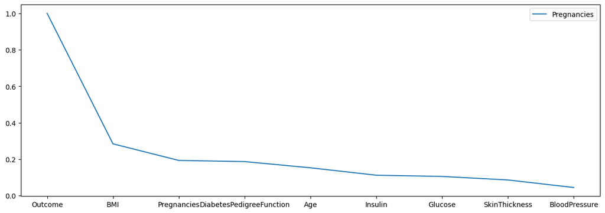

```python
plt.figure(figsize = (15, 5))
plt.plot(corr.iloc[ :, -1])
plt.legend(Data.columns)
```

همانطور که مشاهده می شود BMI و Pregnancies بیشترین وابستگی به Outcome را دارند و میزان وابستگی بقیه ویژگی ها نیز می توان مشاهده کرد.

**4)**

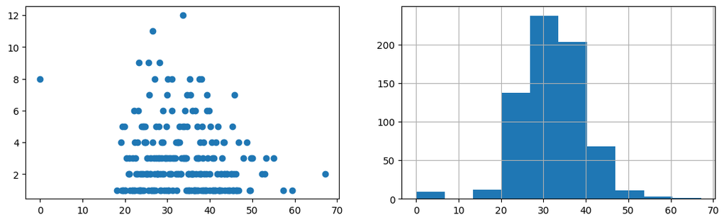

```python
x_value = Data['BMI'].unique()
x_value = x_value[~np.isnan(x_value)]
y_value = Data['BMI'].value_counts()

plt.figure(figsize = (20, 8))
plt.subplot(2,3,1)
plt.scatter(x=x_value, y=y_value)
plt.subplot(2,3,2)
Data['BMI'].hist()

plt.show()
```

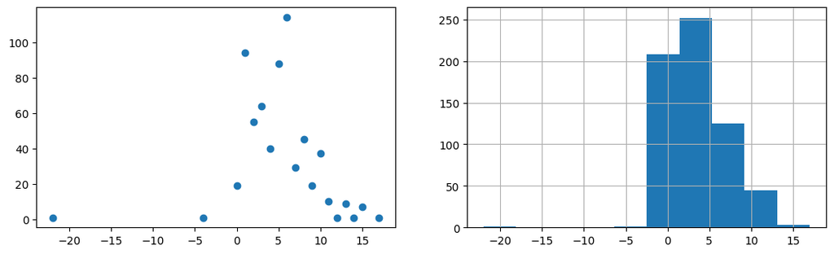

```python
x_value = Data['Pregnancies'].unique()
x_value = x_value[~np.isnan(x_value)]
y_value = Data['Pregnancies'].value_counts()

plt.figure(figsize = (20, 8))
plt.subplot(2,3,1)
plt.scatter(x=x_value, y=y_value)
plt.subplot(2,3,2)
Data['Pregnancies'].hist()
```

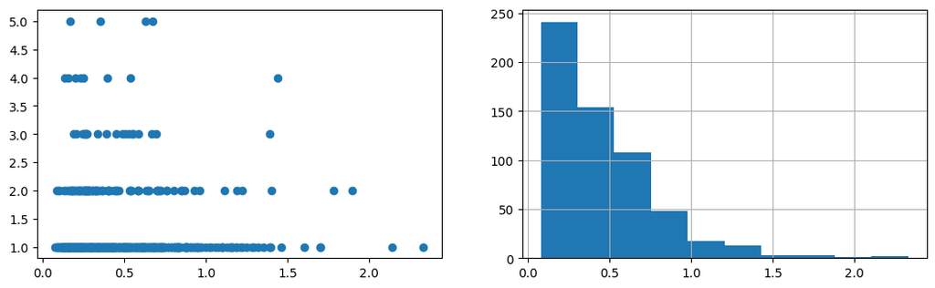

```python
x_value = Data['DiabetesPedigreeFunction'].unique()
x_value = x_value[~np.isnan(x_value)]
y_value = Data['DiabetesPedigreeFunction'].value_counts()

plt.figure(figsize = (20, 8))
plt.subplot(2,3,1)
plt.scatter(x=x_value, y=y_value)
plt.subplot(2,3,2)
Data['DiabetesPedigreeFunction'].hist()
```

**5)**

[figure not shown]

```python
plt.figure(figsize = (20, 8))
plt.subplot(2,3,1)
plt.scatter(x=Data['BMI'], y=Data['Outcome'])
plt.subplot(2,3,2)
plt.hexbin(x=[Data['BMI']], y=Data['Outcome'], gridsize=50, bins='log')
```

[figure not shown]

```python
plt.figure(figsize = (20, 8))
plt.subplot(2,3,1)
plt.scatter(x=Data['Pregnancies'], y=Data['Outcome'])
plt.subplot(2,3,2)
plt.hexbin(x=[Data['Pregnancies']], y=Data['Outcome'], gridsize=50, cmap='inferno')
```

[figure not shown]

```python
plt.figure(figsize = (20, 8))
plt.subplot(2,3,1)
plt.scatter(x=Data['DiabetesPedigreeFunction'], y=Data['Outcome'])
plt.subplot(2,3,2)
plt.hexbin(x=[Data['DiabetesPedigreeFunction']], y=Data['Outcome'], gridsize=50, cmap='inferno')
```

**6)**

در مراحل بعدی کارهایی مانند رسم نمودار information gain ستون ها و درصد خانه های خالی در هر سطر را برای شناخت و اصلاح داده ها مشاهده می کنید.

**پیش پردازش مجموعه داده :**

**1)**

حذف ستون هایی که برخی از مقادیرشان NaN است(یا حذف سطر) :

این روش سریع و آسان است اماممکن است دیتاهای مهمی را که در پیش بینی موثر هستند نیز از دست بدهیم.

پر کردن مقادیر خالی با داده هایی آماری مانند میانه، میانگین، مد یا ... :

در این روش دیتایی از دست نمی رود ولی در ستون هایی که تعداد خانه های NaN زیاد باشد، مقادیر بی معنی زیادی به وجود می آید.

جایگزین کردن یک مقدار مشخص در خانه های حاوی NaN :

می توان یک مقدار خاص را برای جایگزینی در نظر گرفت. مثلا می توان در ستون های عددی مقدار 0 و در ستون هایی از جنس string مقدار " Empty " را جایگزین کرد. در این روش هم ما داده ای از دست نمی دهیم اما مقدار های بی معنی را به داده های خود اضافه کرده ایم.

**2)**

در این بخش برای حل مشکل داده های گمشده از روش زیر استفاده می کنیم:  
یک حد مشخصی برای درصد تعداد خانه های خالی هر ستون و سطر در نظر می گیریم.  
در ستون یا سطر هایی که درصد خانه های خالی بیشتر از این حد بود آن ستون یا سطر را حذف کرده در غیر این صورت مقدار خانه های خالی را با میانگین آن سطر یا ستون جایگزین می کنیم. همچنین سطر هایی که دارای مقادیر منفی هستند را نیز با توجه به دارا بودن اطلاعات غلط حذف می کنیم.

```python
nan_row_percent = Data.apply(get_percent_NaN, axis=1)

# Remove cols and rows that have lots of NaN
limit_remove_col, limit_remove_row = 80, 30 #percent
cols_should_remove = list(nan_col_percent[ nan_col_percent > limit_remove_col].index)
rows_should_remove = list(nan_row_percent[ nan_row_percent > limit_remove_row].index)
Data.drop(cols_should_remove, axis="columns", inplace=True)
Data.drop(rows_should_remove, axis="rows", inplace=True)


# fill NaN cell with mean of col
Data.fillna(Data.mean(), inplace = True)
```

```python
# Remove rows that have negative value
Data = (Data[(Data[Data.columns] >= 0).all(axis=1)])
```

**3)**

Standardization : در این عملیات مقادیر با استفاده از فرمول زیر طوری تغییر می کنند که میانگینشان 0 و انحراف معیار آن ها 1 شود.

$$ x_{2} = \frac{x_{1} - \overline{x}}{\sigma} $$

Normalizing : در این عملیات مقادیر با استفاده از فرمول زیر بین صفر و یک قرار می گیرند

$$ x_{2} = \frac{x_{1} - x_{min}}{x_{max} - x_{min}} $$

```
array([[<AxesSubplot: title={'center': 'Pregnancies'}>,
        <AxesSubplot: title={'center': 'Glucose'}>,
        <AxesSubplot: title={'center': 'BloodPressure'}>],
       [<AxesSubplot: title={'center': 'SkinThickness'}>,
        <AxesSubplot: title={'center': 'Insulin'}>,
        <AxesSubplot: title={'center': 'BMI'}>],
       [<AxesSubplot: title={'center': 'DiabetesPedigreeFunction'}>,
        <AxesSubplot: title={'center': 'Age'}>,
        <AxesSubplot: title={'center': 'Outcome'}>]], dtype=object)
```

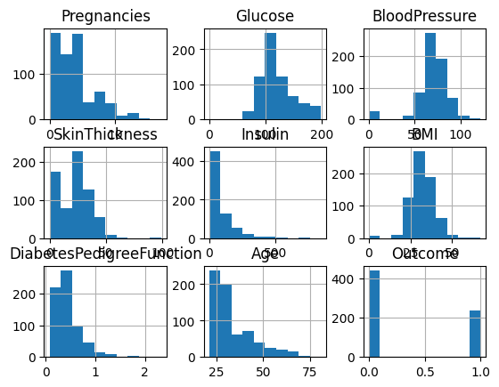

```python
Data.hist()
```

همانطور که در قسمت بالا دیده می شود، نمودار برخی از ستون ها تقریبا به توزیع نرمال نزدیک است و همچنین برای قرار گرفتن مقادیر در یک بازه مشخص تر (به دلیل این که یک مقیاس داشته باشیم و توانایی مقایسه به وجود بیاید)، عملیات Standardization را انجام میدهیم که داده ها به توزیع نرمال استاندارد برسند و اکثر مقادیر در بازه $ [-1, 1] $ قرار گیرند.

```python
def get_normal_col(col_data):
    return (  (col_data - col_data.mean()) / col_data.std()  )

numerical_columns = list((Data.select_dtypes(include=np.number)).columns)
numerical_columns.remove('Outcome')
standard_data = deepcopy(Data)
for col_name in numerical_columns :
    standard_data[col_name] = get_normal_col(Data[col_name])
standard_data
```

|  | Pregnancies | Glucose | BloodPressure | SkinThickness | Insulin | BMI | DiabetesPedigreeFunction | Age | Outcome |
| --- | --- | --- | --- | --- | --- | --- | --- | --- | --- |
| 0 | 0.731123 | 0.910928 | 0.159041 | 0.984708 | -0.709608 | 0.186015 | 0.564463 | 1.498836 | 1 |
| 1 | -0.882255 | -1.201659 | -0.168273 | 0.578910 | -0.709608 | -0.766237 | -0.394455 | -0.198430 | 0 |
| 2 | -0.013130 | 2.084588 | -0.277378 | -1.382447 | -0.709608 | -1.215156 | 0.720808 | -0.109100 | 1 |
| 3 | -0.882255 | -1.067526 | -0.168273 | 0.173112 | 0.131356 | -0.562183 | -1.033733 | -1.091727 | 0 |
| 5 | 0.408447 | -0.162132 | 0.268146 | -1.382447 | 0.002447 | -0.902273 | -0.915606 | -0.025121 | 0 |
| ... | ... | ... | ... | ... | ... | ... | ... | ... | ... |
| 762 | 1.699150 | -1.067526 | -0.386483 | -1.382447 | -0.709608 | -1.323985 | -1.120592 | -0.019770 | 0 |
| 763 | 2.021826 | -0.665129 | 0.377251 | 1.863937 | 0.900748 | 0.090790 | 0.004497 | 2.660123 | 0 |
| 764 | -0.559580 | 0.039067 | 0.049936 | -0.000132 | -0.709608 | 0.621330 | -0.432673 | -0.025121 | 0 |
| 765 | 0.408447 | -0.252789 | 0.159041 | 0.173112 | 0.292391 | -0.820651 | -0.762735 | -0.287759 | 0 |
| 766 | -0.882255 | 0.173199 | -0.495588 | -0.000132 | -0.709608 | -0.290111 | -0.401404 | -0.025121 | 1 |

675 rows × 9 columns

**4)**

One Hot Encoding :

در این روش ستونی که شامل n مقدار منحصر به فرد برای داده های دسته ای است را حذف کرده و n ستون جدید با نام های مقادیر منحصر به فرد درست می کنیم و در هر خانه این ستون ها با توجه به دارا بودن یا نبودن آن ویژگی برای سطر آن خانه مقدار 0 یا 1 می گذاریم.

Label Encoding :

در این روش به هر دسته یک عدد منحصر به فرد نسبت داده می شود. این روش برای داده هایی که دسته های زیادی دارند مناسب تر است تا از ایجاد ستون های زیاد جلوگیری شود.  
به طور کلی انجام این عملیات ها برای ویژگی باید انجام شود که در پیش بینی موثر است.

**5)**

در صورتی که ستون حاوی اطلاعات مهم و موثری برای پیش بینی نباشد و یا مقادیر خانه خالی بسیار زیادی داشته باشد ستون را حذف می کنیم. در واقع در صورتی که یک ویژگی information gain بسیار کمی داشته باشد می توان آن را حذف کرد. در صورتی که این ستون ها را حذف نکنیم ممکن است overfitting رخ دهد.

**6)**

یکی از روش های متداول برای تقسیم داده های اصلی به دو دسته train و test این است که P درصد اول داده ها را برای train انتخاب کنیم و مابقی داده هابرای test انتخاب شوند. نکته بسیار مهم این است که باید داده ها به طور اتفاقی دسته بندی شوند و بهتر است که نسبت outcome های متفاوت به کل داده ها در هر دو دسته test و train برابر باشد.  
دسته بندی اتفاقی داده ها مهم است به این دلیل که باید در هر دو دسته از نتایج مختلف داشته باشیم، مثلا اگر ۱۰۰ داده اول همگی افرادی باشند که دارای دیابت هستند و ما نیز ۱۰۰ داده اول را برای test انتخاب کنیم(یعنی داده ها به طور اتفاقی دسته بندی نشوند) ، نمی توانیم به درستی مدل خود را ارزیابی کنیم، زیرا هیچ موردی که دارای دیابت نباشد در test وجود ندارد.  
برابری نسبت هر خروجی در train و test نیز اهمیت دارد. در داده های train به این دلیل که مدل ما دارای بایاس نشود، یعنی به سمت یک خروجی خاص میل نکند. در داده های test نیز به این دلیل که بتوانیم مدل خود را برای هر خروجی ارزیابی درستی داشته باشیم.  
برای این کار می توانیم از تابع train_test_split در کتاب خانه Scikit-Learn استفاده کنیم.

**7)**

از این دسته داده معمولا برای set کردن hyper parameters استفاده می شود.در واقع قبل از ارزیابی و اجرای مدل بر روی داده test ، با استفاده از داده های validation هایپر پارامترهای مدل خود را تنظیم می کنیم.

**آموزش، ارزیابی و تنظیم :**

```
<BarContainer object of 8 artists>
```

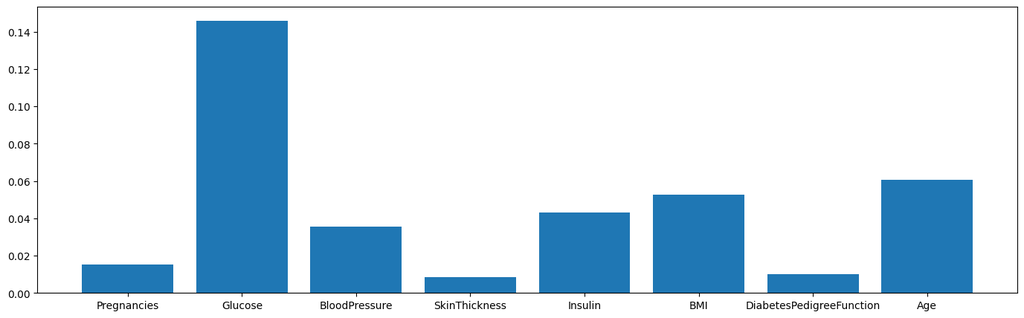

```python
info = sklearn.feature_selection.mutual_info_classif(Data.iloc[:, :-1], Data['Outcome'])
plt.figure(figsize = (17, 5))
plt.bar(Data.columns[:-1], info)
```

```python
del standard_data['BloodPressure']
del standard_data['SkinThickness']
# del standard_data['DiabetesPedigreeFunction']
# del standard_data['Pregnancies']
# del standard_data['Age']

train, test = sklearn.model_selection.train_test_split(standard_data, test_size = 0.25)
train_out_i, test_out_i = len(train.columns)-1, len(test.columns)-1
train_in, train_out = train.iloc[:, :-1], train.iloc[:, train_out_i]
test_in, test_out = test.iloc[:, :-1], test.iloc[:, test_out_i]
```

**1, 2)**

بعد از اجرای هر الگوریتم confusion matrix رسم شده و همچنین محاسبات لازم نمایش داده شده است. در برخی از الگوریتم ها نیز علاوه بر تست کردن دستی مدل با مقادیر مختلف پارامتر ها از تابع GridSearchCV استفاده شده است.

**3)**

Underfitting :

این اتفاق در حالتی که ما مدل خود را به دلایلی مانند بد بودن مقادیر هایپر پارامتر ها یا کم بودن داده train ، خوب آموزش نداده باشیم رخ می دهد. اگر این اتفاق بیفتد مدل ما دقت کمی دارد و پیش بینی خوبی نمی تواند انجام دهد. به عبارتی دیگر زمانی که مدل ما حتی داده های آموزش را به درستی پیش بینی نکند underfitting اتفاق افتاده است که در این مدل ما high bias است.

Overfitting :

اگر ما بیش از حد به جزئیات توجه کنیم و حتی نویز های موجود در داده را نیز مدل کنیم این اتفاق رخ میدهد. در این حالت دقت مدل برای پیش بینی داده های train بسیار بالاست ولی برای داده های test پایین است. در واقع فاصله ای بین دقت داده آموزش و تست وجود دارد که در این مدل ها high variance هستند.  
در مدل هایی که در ادامه پیاده سازی شده اند این اتفاق با توجه به مقادیر مختلف پارامتر ها و نحوه تقسیم بندی داده ها ممکن است بیفتد. برای هر الگوریتم نمودار و معیار های دقت مختلف به طور کامل و دقیق نمایش داده شده است و برای هر الگوریتم به ظور جداگانه محاسبات انجام شده است که در ادامه می توان دید. سعی میکنیم با حذف ستون هایی که information gain بسیار پایینی دارند و تغییر پارامتر های مختلف مدل و همچنین با پیش پردازش هایی که در مراحل قبل انجام دادیم احتمال رخ دادن overfitting را بسیار کم کنیم.

**K-Nearest-Neighbours**

```python
accuracy_train, accuracy_test = [], []
chosen_neighbour = [0, -1] #[ num of neighbours,  accuracy of neighbour]
best_predict = []
neighbours = range(1, 100)
for num_n in neighbours :
    classifier = KNeighborsClassifier(n_neighbors = num_n)
    classifier.fit(train_in, train_out)
    predict_test = classifier.predict(test_in)
    new_acc_train = sm.accuracy_score(train_out, classifier.predict(train_in))
    new_acc_test = sm.accuracy_score(test_out, predict_test)
    accuracy_train.append(new_acc_train)
    accuracy_test.append(new_acc_test)
    if new_acc_test > chosen_neighbour[1] :
        chosen_neighbour[0], chosen_neighbour[1] = num_n, new_acc_test
        best_predict = predict_test
chosen_neighbour
```

```
[13, 0.7869822485207101]
```

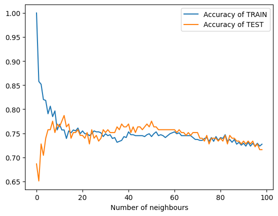

```python
plt.plot(accuracy_train)
plt.plot(accuracy_test)
plt.legend(["Accuracy of TRAIN", "Accuracy of TEST"])
plt.xlabel("Number of neighbours")
```

همانطور که مشاهده می کنید در بعضی مقادیر پارامتر n_neighbors ( مثلا مقدار ۱ ) می توان overfitting را مشاهده کرد( دقت پیش بینی در داده های test کمتر از train است.)

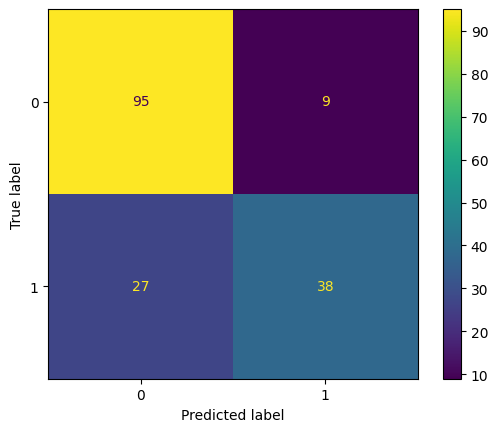

```python
c_matrix = confusion_matrix(test_out, best_predict, labels=classifier.classes_)
display = ConfusionMatrixDisplay(confusion_matrix=c_matrix, display_labels=classifier.classes_)
display.plot()
plt.show()
```

حال با توجه به Confusion matrix می توان با مقادیر مختلف زیر پیش بینی را ارزیابی کرد. مقادیر را از دو روش مختلف محاسبه می کنیم.
$$ Accuracy = \frac{TP + TN}{TP + TN + FP + FN} $$
$$ Precision = \frac{TP}{TP + FP} $$
$$ Recall = \frac{TP}{TP + FN} $$

در این بخش می توان مقادیر را با توجه به ماتریس نمایش داده شده محاسبه کنیم :

$$ Accuracy = \frac{95+38}{95+38+9+27} = \frac{133}{169} = 0.786 $$
$$ Precision = \frac{38}{38 + 9} = \frac{38}{47} = 0.808 $$
$$ Recall = \frac{38}{38 + 27} = \frac{38}{65} = 0.584 $$

```python
accuracy_formula = sm.accuracy_score(test_out, best_predict)
recall_formula = sm.recall_score(test_out, best_predict)
precision_formula = sm.precision_score(test_out, best_predict)
print(f'With Formula :\nAccuracy = {accuracy_formula}\nPrecision = {precision_formula}\nRecall = {recall_formula}')
```

```
With Formula :
Accuracy = 0.7869822485207101
Precision = 0.8085106382978723
Recall = 0.5846153846153846
```

**Decision Trees (change max_depth)**

```python
accuracy_train, accuracy_test = [], []
chosen_depth = [0, -1] #[ depth,  accuracy of depth]
best_predict = []
depths = range(1, 40)
for depth in depths :
    classifier = tree.DecisionTreeClassifier(max_depth = depth)
    classifier.fit(train_in, train_out)
    predict_test = classifier.predict(test_in)
    new_acc_train = sm.accuracy_score(train_out, classifier.predict(train_in))
    new_acc_test = sm.accuracy_score(test_out, predict_test)
    accuracy_train.append(new_acc_train)
    accuracy_test.append(new_acc_test)
    if new_acc_test > chosen_depth[1] :
        chosen_depth[0], chosen_depth[1] = depth, new_acc_test
        best_predict = predict_test
chosen_depth
```

```
[4, 0.7810650887573964]
```

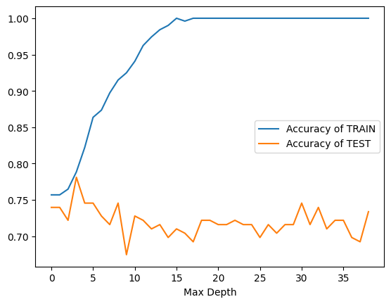

```python
plt.plot(accuracy_train)
plt.plot(accuracy_test)
plt.legend(["Accuracy of TRAIN", "Accuracy of TEST"])
plt.xlabel("Max Depth")
```

در این الگوریتم نیز می توان به وضوح دید که اگر مقدار متغیر max_depth را از حدود ۵ بیشتر کنیم، overfitting اتفاق می افتد.

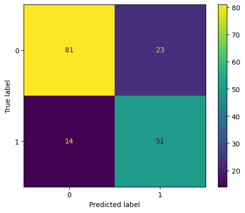

```python
c_matrix = confusion_matrix(test_out, best_predict, labels=classifier.classes_)
display = ConfusionMatrixDisplay(confusion_matrix=c_matrix, display_labels=classifier.classes_)
display.plot()
plt.show()
```

$$ Accuracy = \frac{81+51}{81+51+23+14} = \frac{132}{169} = 0.781 $$
$$ Precision = \frac{51}{51+23} = \frac{51}{74} = 0.689 $$
$$ Recall = \frac{51}{51+14} = \frac{51}{65} = 0.784 $$

```python
accuracy_formula = sm.accuracy_score(test_out, best_predict)
recall_formula = sm.recall_score(test_out, best_predict)
precision_formula = sm.precision_score(test_out, best_predict)
print(f'With Formula :\nAccuracy = {accuracy_formula}\nPrecision = {precision_formula}\nRecall = {recall_formula}')
```

```
With Formula :
Accuracy = 0.7810650887573964
Precision = 0.6891891891891891
Recall = 0.7846153846153846
```

**Decision Trees (change min_samples_leaf)**

```python
accuracy_train, accuracy_test = [], []
chosen_leafs = [0, -1] #[ leafs,  accuracy of leaf]
best_predict = []
leafs = range(1, 500)
for num_leaf in leafs :
    classifier = tree.DecisionTreeClassifier(min_samples_leaf = num_leaf)
    classifier.fit(train_in, train_out)
    predict_test = classifier.predict(test_in)
    new_acc_train = sm.accuracy_score(train_out, classifier.predict(train_in))
    new_acc_test = sm.accuracy_score(test_out, predict_test)
    accuracy_train.append(new_acc_train)
    accuracy_test.append(new_acc_test)
    if new_acc_test > chosen_leafs[1] :
        chosen_leafs[0], chosen_leafs[1] = num_leaf, new_acc_test
        best_predict = predict_test
chosen_leafs
```

```
[19, 0.8224852071005917]
```

```python
mse, bias, variance = bias_variance_decomp(classifier, train_in.values, train_out.values,
                                      test_in.values, test_out.values, loss='mse', num_rounds=100)

print(f"Bias is : {bias}\nVariance is : {variance}")
```

```
Bias is : 0.38461538461538464
Variance is : 0.0
```

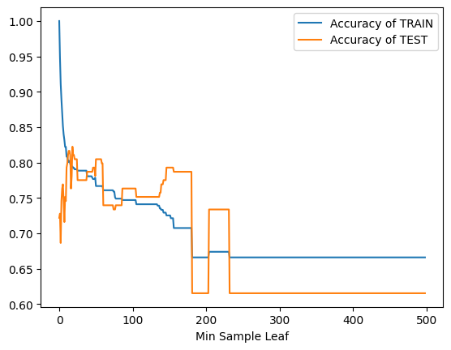

```python
plt.plot(accuracy_train)
plt.plot(accuracy_test)
plt.legend(["Accuracy of TRAIN", "Accuracy of TEST"])
plt.xlabel("Min Sample Leaf")
```

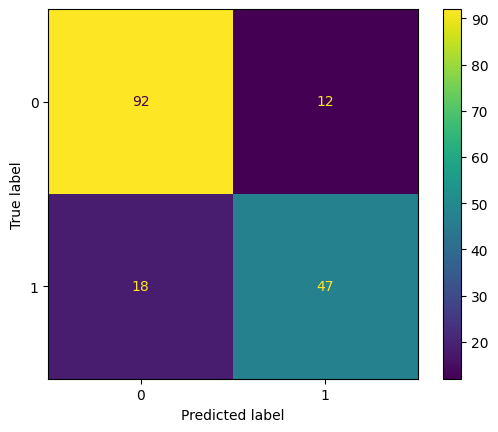

```python
c_matrix = confusion_matrix(test_out, best_predict, labels=classifier.classes_)
display = ConfusionMatrixDisplay(confusion_matrix=c_matrix, display_labels=classifier.classes_)
display.plot()
plt.show()
```

$$ Accuracy = \frac{92+47}{92+47+12+18} = \frac{139}{169} = 0.822 $$
$$ Precision = \frac{47}{47+12} = \frac{47}{59} = 0.796 $$
$$ Recall = \frac{47}{47+18} = \frac{47}{65} = 0.723 $$

```python
accuracy_formula = sm.accuracy_score(test_out, best_predict)
recall_formula = sm.recall_score(test_out, best_predict)
precision_formula = sm.precision_score(test_out, best_predict)
print(f'With Formula :\nAccuracy = {accuracy_formula}\nPrecision = {precision_formula}\nRecall = {recall_formula}')
```

```
With Formula :
Accuracy = 0.8224852071005917
Precision = 0.7966101694915254
Recall = 0.7230769230769231
```

```python
param_grid = {
              'max_depth': [1, 2, 3, 4, 10,17, 18, 20, 22, 24, 26],
              'min_samples_split': [1, 2, 3, 4],
              'min_samples_leaf': [25, 24, 20, 26, 38, 39, 40, 41, 42, 100, 150, 1000]
#               'max_features':["auto", "sqrt", "log2", None],
             }
gs_lr = GridSearchCV(classifier, param_grid,n_jobs = -1, verbose = 0, scoring = 'accuracy', cv = 5)
gs_lr.fit(train_in, train_out)

print(gs_lr.best_params_)
print(gs_lr.score(train_in, train_out))
print(gs_lr.score(test_in, test_out))
```

```
{'max_depth': 1, 'min_samples_leaf': 25, 'min_samples_split': 1}
0.7569169960474308
0.7396449704142012
```

**Logistic Regression**

```python
accuracy_train, accuracy_test = [], []
chosen = [0, -1]
best_predict = []
iters = range(1, 20)
for i in iters :
    classifier = LogisticRegression(max_iter = i, random_state=4)
    classifier.fit(train_in, train_out)
    predict_test = classifier.predict(test_in)
    new_acc_train = sm.accuracy_score(train_out, classifier.predict(train_in))
    new_acc_test = sm.accuracy_score(test_out, predict_test)
    accuracy_train.append(new_acc_train)
    accuracy_test.append(new_acc_test)
    if new_acc_test > chosen[1] :
        chosen[0], chosen[1] = i, new_acc_test
        best_predict = predict_test
chosen
```

```
[3, 0.7692307692307693]
```

```python
mse, bias, variance = bias_variance_decomp(classifier, train_in.values, train_out.values,
                                      test_in.values, test_out.values, loss='mse', num_rounds=100)

print(f"Bias is : {bias}\nVariance is : {variance}")
```

```
Bias is : 0.1947136094674556
Variance is : 0.03522721893491124
```

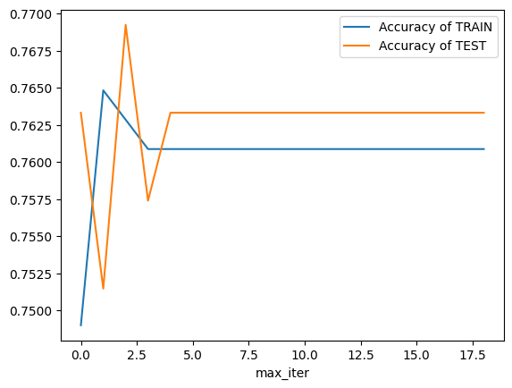

```python
plt.plot(accuracy_train)
plt.plot(accuracy_test)
plt.legend(["Accuracy of TRAIN", "Accuracy of TEST"])
plt.xlabel("max_iter")
```

در این حالت همانطور که مشاهده می شود دقت بین داده آموزش و تست بسیار نزدیک هستند و تقریبا می توان گفت overfitting در بیشتر مقادیر اتفاق نیفتاده است. در ادامه با کمک تابع GridSearchCV مقدار مناسب برای هر پارامتر را پیدا می کنیم.

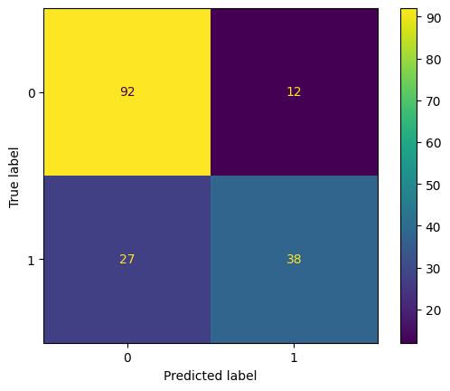

```python
c_matrix = confusion_matrix(test_out, best_predict, labels=classifier.classes_)
display = ConfusionMatrixDisplay(confusion_matrix=c_matrix, display_labels=classifier.classes_)
display.plot()
plt.show()
```

$$ Accuracy = \frac{92+38}{92+38+12+27} = \frac{130}{169} = 0.769 $$
$$ Precision = \frac{38}{38+12} = \frac{38}{50} = 0.76$$
$$ Recall = \frac{38}{38+27} = \frac{38}{65} = 0.584 $$

```python
accuracy_formula = sm.accuracy_score(test_out, best_predict)
recall_formula = sm.recall_score(test_out, best_predict)
precision_formula = sm.precision_score(test_out, best_predict)
print(f'With Formula :\nAccuracy = {accuracy_formula}\nPrecision = {precision_formula}\nRecall = {recall_formula}')
```

```
With Formula :
Accuracy = 0.7692307692307693
Precision = 0.76
Recall = 0.5846153846153846
```

```python
param_grid = {'penalty':('l1','l2', "elasticnet"),
             'tol':(0.0001, 0.00001, 0.00005),
             'C':(0.01, 0.1, 0.5, 1, 1.3, 1.5, 1.8, 2, 3),
#              'solver':("lbfgs", "liblinear", "newton-cg", "newton-cholesky", "sag", "saga"),
#               'max_iter':(5, 10, 30, 50, 100, 150, 200, 250)
             }
classifier = LogisticRegression()
gs_lr = GridSearchCV(classifier, param_grid,n_jobs = -1, verbose = 0, scoring = 'accuracy', cv = 5)
gs_lr.fit(train_in, train_out)
print(gs_lr.best_params_)
print(gs_lr.score(train_in, train_out))
print(gs_lr.score(test_in, test_out))
```

```
{'C': 0.1, 'penalty': 'l2', 'tol': 0.0001}
0.7628458498023716
0.757396449704142
```

**روش های یادگیری جمعی :**

**۱)**

max_depth :

حداکثر ارتفاع هر درخت را در جنگل مشحص می کند.

n_estimators :

این متغیر تعداد درختان جنگل را مشخص میکند.

leaf_samples_min :

مقدار این متغیر حداقل میزان اسپلیت را مشخص میکند. یعنی اگر مثلا مقدار این متغیر برابر 5 باشد، زمانی که اسپلیت کردن یک راس به کمتر از 5 برسد کار ادامه پیدا می کند.

تاثیر تغییر این پارامتر ها بر روی نتیجه را به طور کامل با رسم نمودار و ذکر نتایج در پایین هر کدام از بخش های زیر می توانید مشاهده کنید.

**Random Forest(max_depth)**

```python
del standard_data['DiabetesPedigreeFunction']
# del standard_data['Pregnancies']
# del standard_data['Age']

train, test = sklearn.model_selection.train_test_split(standard_data, test_size = 0.25)
train_out_i, test_out_i = len(train.columns)-1, len(test.columns)-1
train_in, train_out = train.iloc[:, :-1], train.iloc[:, train_out_i]
test_in, test_out = test.iloc[:, :-1], test.iloc[:, test_out_i]
```

```python
accuracy_train, accuracy_test = [], []
chosen = [0, -1]
best_predict = []
iters = range(1, 60)
for i in iters :
    classifier = RandomForestClassifier(max_depth = i)
    classifier.fit(train_in, train_out)
    predict_test = classifier.predict(test_in)
    new_acc_train = sm.accuracy_score(train_out, classifier.predict(train_in))
    new_acc_test = sm.accuracy_score(test_out, predict_test)
    accuracy_train.append(new_acc_train)
    accuracy_test.append(new_acc_test)
    if new_acc_test > chosen[1] :
        chosen[0], chosen[1] = i, new_acc_test
        best_predict = predict_test
chosen
```

```
[2, 0.7988165680473372]
```

```python
mse, bias, variance = bias_variance_decomp(classifier, train_in.values, train_out.values,
                                      test_in.values, test_out.values, loss='mse', num_rounds=100)

print(f"Bias is : {bias}\nVariance is : {variance}")
```

```
Bias is : 0.1730698224852071
Variance is : 0.05604260355029586
```

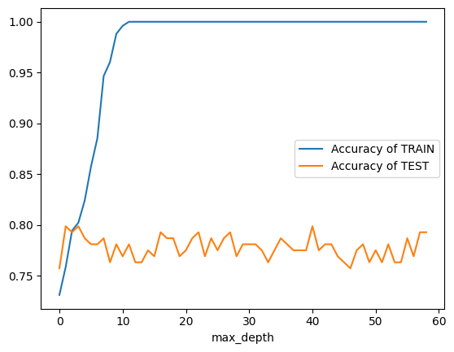

```python
plt.plot(accuracy_train)
plt.plot(accuracy_test)
plt.legend(["Accuracy of TRAIN", "Accuracy of TEST"])
plt.xlabel("max_depth")
```

افزایش مقدار max_depth با توجه به بیشتر شدن حداکثر ارتفاع هر درخت باعث می شود مدل ما با داده آموزش بهتر فیت شود و احتمال overfitting بیشتر میشود. همانطور که در نمودار های رسم شده مشاهده می کنید با افزایش این مقدار به وضوح overfitting مشاهده می شود در نتیجه مقدار variance افزایش (به دلیل بیشتر شدن تفاوت دقت پیش بینی در داده آموزش و تست) و مقدار bias کاهش می یابد(بالا رفتن دقت پیش بینی داده آموزش)

[output not shown]

```python
accuracy_formula = sm.accuracy_score(test_out, best_predict)
recall_formula = sm.recall_score(test_out, best_predict)
precision_formula = sm.precision_score(test_out, best_predict)
print(f'With Formula :\nAccuracy = {accuracy_formula}\nPrecision = {precision_formula}\nRecall = {recall_formula}')
```

```
With Formula :
Accuracy = 0.7988165680473372
Precision = 0.9032258064516129
Recall = 0.4745762711864407
```

**Random Forest(min_samples_leaf)**

```python
accuracy_train, accuracy_test = [], []
chosen = [0, -1]
best_predict = []
iters = range(1, 80)
for i in iters :
    classifier = RandomForestClassifier(min_samples_leaf = i)
    classifier.fit(train_in, train_out)
    predict_test = classifier.predict(test_in)
    new_acc_train = sm.accuracy_score(train_out, classifier.predict(train_in))
    new_acc_test = sm.accuracy_score(test_out, predict_test)
    accuracy_train.append(new_acc_train)
    accuracy_test.append(new_acc_test)
    if new_acc_test > chosen[1] :
        chosen[0], chosen[1] = i, new_acc_test
        best_predict = predict_test
chosen
```

```
[11, 0.8106508875739645]
```

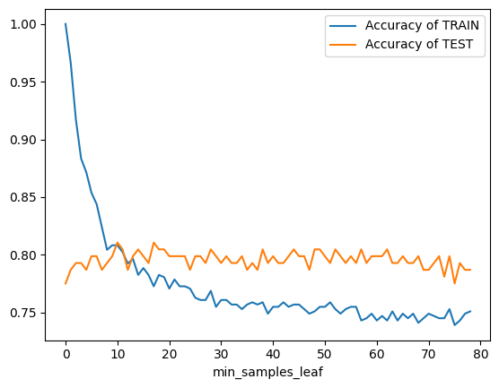

```python
plt.plot(accuracy_train)
plt.plot(accuracy_test)
plt.legend(["Accuracy of TRAIN", "Accuracy of TEST"])
plt.xlabel("min_samples_leaf")
```

همانطور که مشاهده می کنید با افزایش مقدار min_samples_leaf شاهد افزایش bias (کاهش دقت داده آموزش) هستیم. همچنین افزایش این مقدار تا یک حدی باعث می شود variance کاهش یابد زیرا تفاوت دقت بین داده آموزش و تست کمتر می شود و پس از آن تفاوت بیشتر می شود.

```python
accuracy_formula = sm.accuracy_score(test_out, best_predict)
recall_formula = sm.recall_score(test_out, best_predict)
precision_formula = sm.precision_score(test_out, best_predict)
print(f'With Formula :\nAccuracy = {accuracy_formula}\nPrecision = {precision_formula}\nRecall = {recall_formula}')
```

```
With Formula :
Accuracy = 0.8106508875739645
Precision = 0.813953488372093
Recall = 0.5932203389830508
```

**Random Forest(n_estimators)**

```python
accuracy_train, accuracy_test = [], []
chosen = [0, -1]
best_predict = []
iters = range(1, 80)
for i in iters :
    classifier = RandomForestClassifier(n_estimators = i)
    classifier.fit(train_in, train_out)
    predict_test = classifier.predict(test_in)
    new_acc_train = sm.accuracy_score(train_out, classifier.predict(train_in))
    new_acc_test = sm.accuracy_score(test_out, predict_test)
    accuracy_train.append(new_acc_train)
    accuracy_test.append(new_acc_test)
    if new_acc_test > chosen[1] :
        chosen[0], chosen[1] = i, new_acc_test
        best_predict = predict_test
chosen
```

```
[41, 0.8047337278106509]
```

```python
mse, bias, variance = bias_variance_decomp(classifier, train_in.values, train_out.values,
                                      test_in.values, test_out.values, loss='mse', num_rounds=100)

print(f"Bias is : {bias}\nVariance is : {variance}")
```

```
Bias is : 0.17199644970414202
Variance is : 0.05889112426035503
```

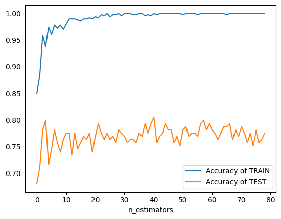

```python
plt.plot(accuracy_train)
plt.plot(accuracy_test)
plt.legend(["Accuracy of TRAIN", "Accuracy of TEST"])
plt.xlabel("n_estimators")
```

با افزایش مقدار n_estimators شاهد کاهش bias (بیشتر شدن دقت داده آموزش) هستیم. با توجه به این که با افزودن این مقدار ممکن است درخت ها به یک دیگر وابسته شوند می بینید که همچنان واریانس به دلیل تفاوت میان دقت داده آموزش و تست وجود دارد.

```python
accuracy_formula = sm.accuracy_score(test_out, best_predict)
recall_formula = sm.recall_score(test_out, best_predict)
precision_formula = sm.precision_score(test_out, best_predict)
print(f'With Formula :\nAccuracy = {accuracy_formula}\nPrecision = {precision_formula}\nRecall = {recall_formula}')
```

```
With Formula :
Accuracy = 0.8047337278106509
Precision = 0.8095238095238095
Recall = 0.576271186440678
```

**2)**